# Nicky Lopez

```r
install.packages("rtweet")
library(tidyverse)
library(rtweet)
library(ggplot2)
library(dplyr)
theme_set(theme_bw())
```

Royals shortshop Nicky Lopez is a rare player in today’s baseball landscape. Today’s game is primarily focused on two factors: the launch angle of the ball off of the bat and the exit velocity of that ball. Teams prioritize good exit velocities and launch angles, and thus, home runs. Let’s look at where Nicky Lopez ranked in those three factors in 2021:

```r
statcastLeaderboards <- read.csv("Final Project/FanGraphs Statcast Leaderboard.csv")

exitVelocity <- statcastLeaderboards %>%
  select(ï..Name, EV) %>%
  arrange(desc(EV))
```

[output not shown]

Nicky Lopez ranked 231st in average exit velocity… out of 262 players. He doesn’t hit the ball very hard. Let’s look at his average launch angle:

```r
launchAngle <- statcastLeaderboards %>%
  select(ï..Name, LA) %>%
  arrange(desc(LA))
```

```r
hittingLeaderboards <- read.csv("Final Project/FanGraphs Hitting Leaderboard.csv")

homeRuns <- hittingLeaderboards %>%
  select(ï..Name, HR) %>%
  arrange(desc(HR))
```

```r
perezEV <- statcastLeaderboards %>%
  select(ï..Name, EV) %>%
  arrange(desc(EV))

perezLA <- statcastLeaderboards %>%
  select(ï..Name, LA) %>%
  arrange(desc(LA))
```

```r
winsAboveReplacement <- hittingLeaderboards %>%
  select(ï..Name, WAR) %>%
  arrange(desc(WAR))
```

WAR stands for Wins Above Replacement. Here’s MLB’s official explanation of the statistic: “WAR measures a player’s value in all facets of the game by deciphering how many more wins he’s worth than a replacement-level player at his same position (e.g., a Minor League replacement or a readily available fill-in free agent).”

fWAR just refers to the fact that Fangraphs did the WAR calculation–different organizations calculate WAR slightly differently, but the gist is the same. fWAR just takes into account defense a bit more than other calculations of WAR. WAR is considered the go to stat to find a player’s ability in one number. Whoever finishes the season with the most WAR is usually the best player in baseball.

A WAR of 2.0 is about average. Nicky’s was 4.4! Here’s a graph comparing Lopez’s fWAR to every hitter’s fWAR from Major League Baseball’s 2021 All-Star team (which he was not elected to).

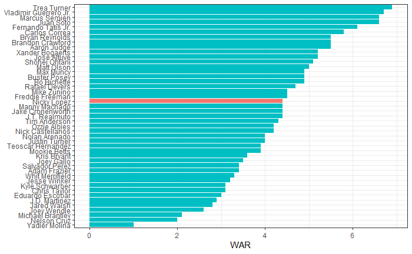

```r
allStars <- c("Salvador Perez", "Nicky Lopez", "Vladimir Guerrero Jr.", "Marcus Semien", "Rafael Devers","Xander Bogaerts", "Mike Trout", "Aaron Judge", "Teoscar Hernandez", "Shohei Ohtani", "Mike Zunino", "Jose Altuve", "Whit Merrifield", "Bo Bichette", "Carlos Correa", "Tim Anderson", "Joey Wendle", "Matt Olson", "José Ramírez", "Jared Walsh", "Michael Brantley", "Joey Gallo", "Adolis García", "Cedric Mullins", "J.D. Martinez", "Nelson Cruz", "Buster Posey", "Freddie Freeman", "Adam Frazier", "Nolan Arenado", "Fernando Tatis Jr.", "Ronald Acuña Jr.", "Nick Castellanos", "Jesse Winker", "J.T. Realmuto", "Yadier Molina", "Omar Narváez", "Ozzie Albies", "Kris Bryant", "Brandon Crawford", "Jake Cronenworth", "Eduardo Escobar", "Justin Turner", "Manny Machado", "Max Muncy", "Trea Turner", "Mookie Betts", "Bryan Reynolds", "Kyle Schwarber", "Juan Soto", "Chris Taylor")

winsAboveReplacementAllStars <- hittingLeaderboards %>%
  filter(ï..Name %in% allStars) %>%
  select(ï..Name, WAR) %>%
  arrange(desc(WAR))

ggplot(winsAboveReplacementAllStars, aes(x=reorder(ï..Name, +WAR), y=WAR, fill = ifelse(ï..Name == "Nicky Lopez", "Highlighted", "Normal"))) +
  geom_bar(stat='identity') +
  theme(legend.position = "none", axis.title.y = element_blank()) +
  coord_flip()
```

Lopez is better than more than half of the 2021 all-stars. That is an incredible feat for someone who was rarely talked about on a national stage. Here’s some twitter data on how many times tweets that mentioned “MLB” tweeted about Freddie Freeman, who finished just one spot ahead of Nicky in fWAR, compared to Nicky Lopez.

```r
baseballTweets <- search_tweets(
  "MLB", n = 18000, include_rts = FALSE
)
```

[output not shown]

[output cut: 65 more lines]

[output not shown]

```r
baseballTweets %>%
  select(text) %>%
  filter(grepl('Nicky Lopez', text)) %>%
  count()
```

| n |
| --- |
| 0 |

```r
baseballTweets %>%
  select(text) %>%
  filter(grepl('Freddie Freeman', text)) %>%
  count()
```

| n |
| --- |
| 25 |

So, that’s why I’m talking about Nicky Lopez: he’s an extremely unique and underrated player. But what exactly about his play contributes to this high fWAR? We’ve already established he doesn’t hit the ball like you’re supposed to, which should mean he’s a bad hitter, right? Let’s look at two things that contribute to his high fWAR: his defense and his luck. Let’s start with his luck using the stat BABIP. BABIP stands for batting average on balls in play. In other words, it’s a players batting average exclusively on balls that had to be defended against–no strikeouts.

So there you have it! An in-depth analysis of Nicky Lopez, one of the most underrated, luckiest and simultaneously most skilled players of 2021.

Methodology: All of data used here comes from Fangraphs, a baseball statistics website that is the industry standard in sabermetric analysis. They also provide data from Baseball Savant, which is run by MLB themselves, on their website. Baseball Savant uses advanced technology to track ball speed, trajectory and a variety of advanced metrics using equipment set up at all 30 MLB stadiums.

Geography is the location of all 30 baseball stadiums around the United States. The time period is the 2021 baseball season.

As with all sabermetric analysis, the stats themselves do have an inherant bias but are generally regarded as pretty accurate in their assessment of a player’s talent.